# Risk Factor Analysis

## Outcome Variable

**Outcome Variable:** s03rec24

## Predictor Variables

**Intervention Variable:** enwast

**Adjustment Set:**

- arm
- sex
- W_mage
- meducyrs
- hhwealth_quart
- brthmon
- W_parity
- delta_W_mage
- delta_meducyrs
- delta_hhwealth_quart
- delta_brthmon
- delta_W_parity

## Stratifying Variables

The analysis was stratified on these variable(s):

- studyid
- country

## Data Summary

| studyid | country | enwast | s03rec24 | n_cell | n |
| --- | --- | --- | --- | --- | --- |
| ki0047075b-MAL-ED | BANGLADESH | 0 | 0 | 188 | 236 |
| ki0047075b-MAL-ED | BANGLADESH | 0 | 1 | 6 | 236 |
| ki0047075b-MAL-ED | BANGLADESH | 1 | 0 | 41 | 236 |
| ki0047075b-MAL-ED | BANGLADESH | 1 | 1 | 1 | 236 |
| ki0047075b-MAL-ED | BRAZIL | 0 | 0 | 197 | 217 |
| ki0047075b-MAL-ED | BRAZIL | 0 | 1 | 13 | 217 |
| ki0047075b-MAL-ED | BRAZIL | 1 | 0 | 7 | 217 |
| ki0047075b-MAL-ED | BRAZIL | 1 | 1 | 0 | 217 |
| ki0047075b-MAL-ED | INDIA | 0 | 0 | 191 | 243 |
| ki0047075b-MAL-ED | INDIA | 0 | 1 | 10 | 243 |
| ki0047075b-MAL-ED | INDIA | 1 | 0 | 39 | 243 |
| ki0047075b-MAL-ED | INDIA | 1 | 1 | 3 | 243 |
| ki0047075b-MAL-ED | NEPAL | 0 | 0 | 198 | 235 |
| ki0047075b-MAL-ED | NEPAL | 0 | 1 | 9 | 235 |
| ki0047075b-MAL-ED | NEPAL | 1 | 0 | 26 | 235 |
| ki0047075b-MAL-ED | NEPAL | 1 | 1 | 2 | 235 |
| ki0047075b-MAL-ED | PERU | 0 | 0 | 256 | 279 |
| ki0047075b-MAL-ED | PERU | 0 | 1 | 18 | 279 |
| ki0047075b-MAL-ED | PERU | 1 | 0 | 5 | 279 |
| ki0047075b-MAL-ED | PERU | 1 | 1 | 0 | 279 |
| ki0047075b-MAL-ED | SOUTH AFRICA | 0 | 0 | 263 | 301 |
| ki0047075b-MAL-ED | SOUTH AFRICA | 0 | 1 | 16 | 301 |
| ki0047075b-MAL-ED | SOUTH AFRICA | 1 | 0 | 19 | 301 |
| ki0047075b-MAL-ED | SOUTH AFRICA | 1 | 1 | 3 | 301 |
| ki0047075b-MAL-ED | TANZANIA, UNITED REPUBLIC OF | 0 | 0 | 241 | 244 |
| ki0047075b-MAL-ED | TANZANIA, UNITED REPUBLIC OF | 0 | 1 | 0 | 244 |
| ki0047075b-MAL-ED | TANZANIA, UNITED REPUBLIC OF | 1 | 0 | 3 | 244 |
| ki0047075b-MAL-ED | TANZANIA, UNITED REPUBLIC OF | 1 | 1 | 0 | 244 |
| ki1000108-CMC-V-BCS-2002 | INDIA | 0 | 0 | 259 | 363 |
| ki1000108-CMC-V-BCS-2002 | INDIA | 0 | 1 | 6 | 363 |
| ki1000108-CMC-V-BCS-2002 | INDIA | 1 | 0 | 90 | 363 |
| ki1000108-CMC-V-BCS-2002 | INDIA | 1 | 1 | 8 | 363 |
| ki1000108-IRC | INDIA | 0 | 0 | 238 | 388 |
| ki1000108-IRC | INDIA | 0 | 1 | 18 | 388 |
| ki1000108-IRC | INDIA | 1 | 0 | 129 | 388 |
| ki1000108-IRC | INDIA | 1 | 1 | 3 | 388 |
| ki1000109-EE | PAKISTAN | 0 | 0 | 312 | 350 |
| ki1000109-EE | PAKISTAN | 0 | 1 | 0 | 350 |
| ki1000109-EE | PAKISTAN | 1 | 0 | 38 | 350 |
| ki1000109-EE | PAKISTAN | 1 | 1 | 0 | 350 |
| ki1000109-ResPak | PAKISTAN | 0 | 0 | 136 | 166 |
| ki1000109-ResPak | PAKISTAN | 0 | 1 | 0 | 166 |
| ki1000109-ResPak | PAKISTAN | 1 | 0 | 30 | 166 |
| ki1000109-ResPak | PAKISTAN | 1 | 1 | 0 | 166 |
| ki1017093b-PROVIDE | BANGLADESH | 0 | 0 | 522 | 682 |
| ki1017093b-PROVIDE | BANGLADESH | 0 | 1 | 14 | 682 |
| ki1017093b-PROVIDE | BANGLADESH | 1 | 0 | 141 | 682 |
| ki1017093b-PROVIDE | BANGLADESH | 1 | 1 | 5 | 682 |
| ki1066203-TanzaniaChild2 | TANZANIA, UNITED REPUBLIC OF | 0 | 0 | 2130 | 2267 |
| ki1066203-TanzaniaChild2 | TANZANIA, UNITED REPUBLIC OF | 0 | 1 | 2 | 2267 |
| ki1066203-TanzaniaChild2 | TANZANIA, UNITED REPUBLIC OF | 1 | 0 | 135 | 2267 |
| ki1066203-TanzaniaChild2 | TANZANIA, UNITED REPUBLIC OF | 1 | 1 | 0 | 2267 |
| ki1101329-Keneba | GAMBIA | 0 | 0 | 2268 | 2458 |
| ki1101329-Keneba | GAMBIA | 0 | 1 | 72 | 2458 |
| ki1101329-Keneba | GAMBIA | 1 | 0 | 113 | 2458 |
| ki1101329-Keneba | GAMBIA | 1 | 1 | 5 | 2458 |
| ki1113344-GMS-Nepal | NEPAL | 0 | 0 | 958 | 1182 |
| ki1113344-GMS-Nepal | NEPAL | 0 | 1 | 28 | 1182 |
| ki1113344-GMS-Nepal | NEPAL | 1 | 0 | 196 | 1182 |
| ki1113344-GMS-Nepal | NEPAL | 1 | 1 | 0 | 1182 |
| ki1114097-CMIN | BANGLADESH | 0 | 0 | 221 | 249 |
| ki1114097-CMIN | BANGLADESH | 0 | 1 | 11 | 249 |
| ki1114097-CMIN | BANGLADESH | 1 | 0 | 17 | 249 |
| ki1114097-CMIN | BANGLADESH | 1 | 1 | 0 | 249 |
| ki1114097-CMIN | PERU | 0 | 0 | 706 | 738 |
| ki1114097-CMIN | PERU | 0 | 1 | 1 | 738 |
| ki1114097-CMIN | PERU | 1 | 0 | 31 | 738 |
| ki1114097-CMIN | PERU | 1 | 1 | 0 | 738 |
| ki1114097-CONTENT | PERU | 0 | 0 | 199 | 214 |
| ki1114097-CONTENT | PERU | 0 | 1 | 14 | 214 |
| ki1114097-CONTENT | PERU | 1 | 0 | 1 | 214 |
| ki1114097-CONTENT | PERU | 1 | 1 | 0 | 214 |

The following strata were considered:

- studyid: ki0047075b-MAL-ED, country: BANGLADESH
- studyid: ki0047075b-MAL-ED, country: BRAZIL
- studyid: ki0047075b-MAL-ED, country: INDIA
- studyid: ki0047075b-MAL-ED, country: NEPAL
- studyid: ki0047075b-MAL-ED, country: PERU
- studyid: ki0047075b-MAL-ED, country: SOUTH AFRICA
- studyid: ki0047075b-MAL-ED, country: TANZANIA, UNITED REPUBLIC OF
- studyid: ki1000108-CMC-V-BCS-2002, country: INDIA
- studyid: ki1000108-IRC, country: INDIA
- studyid: ki1000109-EE, country: PAKISTAN
- studyid: ki1000109-ResPak, country: PAKISTAN
- studyid: ki1017093b-PROVIDE, country: BANGLADESH
- studyid: ki1066203-TanzaniaChild2, country: TANZANIA, UNITED REPUBLIC OF
- studyid: ki1101329-Keneba, country: GAMBIA
- studyid: ki1113344-GMS-Nepal, country: NEPAL
- studyid: ki1114097-CMIN, country: BANGLADESH
- studyid: ki1114097-CMIN, country: PERU
- studyid: ki1114097-CONTENT, country: PERU

### Dropped Strata

Some strata were dropped due to rare outcomes:

- studyid: ki0047075b-MAL-ED, country: BANGLADESH
- studyid: ki0047075b-MAL-ED, country: BRAZIL
- studyid: ki0047075b-MAL-ED, country: INDIA
- studyid: ki0047075b-MAL-ED, country: NEPAL
- studyid: ki0047075b-MAL-ED, country: PERU
- studyid: ki0047075b-MAL-ED, country: SOUTH AFRICA
- studyid: ki0047075b-MAL-ED, country: TANZANIA, UNITED REPUBLIC OF
- studyid: ki1000108-IRC, country: INDIA
- studyid: ki1000109-EE, country: PAKISTAN
- studyid: ki1000109-ResPak, country: PAKISTAN
- studyid: ki1066203-TanzaniaChild2, country: TANZANIA, UNITED REPUBLIC OF
- studyid: ki1113344-GMS-Nepal, country: NEPAL
- studyid: ki1114097-CMIN, country: BANGLADESH
- studyid: ki1114097-CMIN, country: PERU
- studyid: ki1114097-CONTENT, country: PERU

## Methods Detail

We’re interested in the causal parameters $E[Y_a]$ for all values of $a \in \mathcal{A}$. These parameters represent the mean outcome if, possibly contrary to fact, we intervened to set all units to have $A=a$. Under the randomization and positivity assumptions, these are identified by the statistical parameters $\psi_a=E_W[E_{Y|A,W}(Y|A=a,W)]$. In addition, we’re interested in the mean of $Y$, $E[Y]$ under no intervention (the observed mean). We will estimate these parameters by using SuperLearner to fit the relevant likelihood factors – $E_{Y|A,W}(Y|A=a,W)$ and $p(A=a|W)$, and then updating our likelihood fit using a joint TMLE.

For unadjusted analyses ($W=\{\}$), initial likelihoods were estimated using Lrnr_glm to estimate the simple $E(Y|A)$ and Lrnr_mean to estimate $p(A)$. For adjusted analyses, a small library containing Lrnr_glmnet, Lrnr_xgboost, and Lrnr_mean was used.

Having estimated these parameters, we will then use the delta method to estimate relative risks and attributable risks relative to a prespecified baseline level of $A$.

# Results Detail

## Results Plots

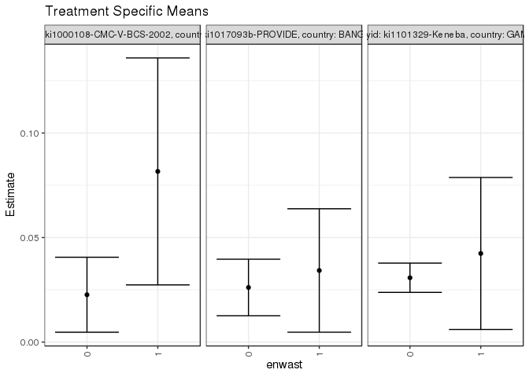

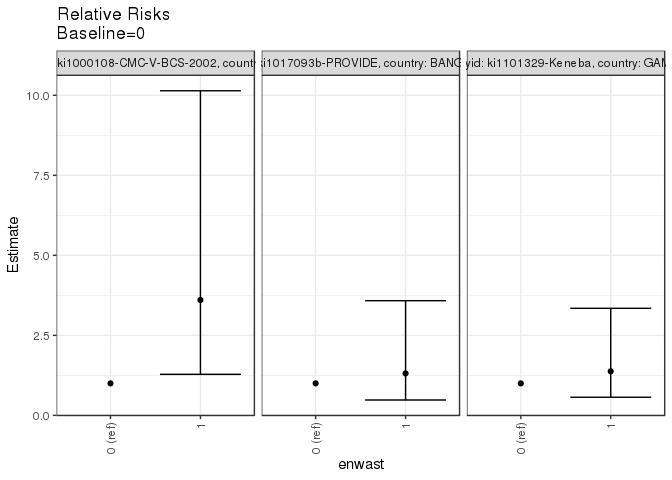

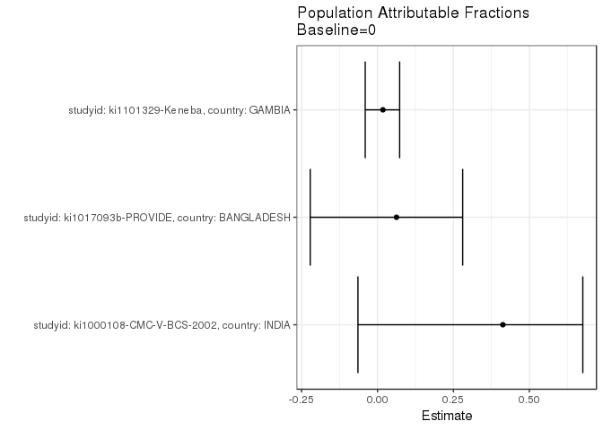

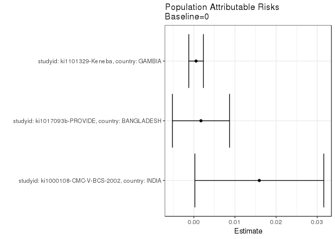

## Results Table

### Parameter: TSM

| studyid | country | intervention_level | baseline_level | estimate | ci_lower | ci_upper |
| --- | --- | --- | --- | --- | --- | --- |
| ki1000108-CMC-V-BCS-2002 | INDIA | 0 | NA | 0.0226415 | 0.0047064 | 0.0405766 |
| ki1000108-CMC-V-BCS-2002 | INDIA | 1 | NA | 0.0816327 | 0.0273484 | 0.1359170 |
| ki1017093b-PROVIDE | BANGLADESH | 0 | NA | 0.0261194 | 0.0126074 | 0.0396314 |
| ki1017093b-PROVIDE | BANGLADESH | 1 | NA | 0.0342466 | 0.0047255 | 0.0637676 |
| ki1101329-Keneba | GAMBIA | 0 | NA | 0.0307692 | 0.0237708 | 0.0377677 |
| ki1101329-Keneba | GAMBIA | 1 | NA | 0.0423729 | 0.0060201 | 0.0787257 |

### Parameter: E(Y)

| studyid | country | intervention_level | baseline_level | estimate | ci_lower | ci_upper |
| --- | --- | --- | --- | --- | --- | --- |
| ki1000108-CMC-V-BCS-2002 | INDIA | NA | NA | 0.0385675 | 0.0187310 | 0.0584039 |
| ki1017093b-PROVIDE | BANGLADESH | NA | NA | 0.0278592 | 0.0154991 | 0.0402194 |
| ki1101329-Keneba | GAMBIA | NA | NA | 0.0313263 | 0.0244384 | 0.0382142 |

### Parameter: RR

| studyid | country | intervention_level | baseline_level | estimate | ci_lower | ci_upper |
| --- | --- | --- | --- | --- | --- | --- |
| ki1000108-CMC-V-BCS-2002 | INDIA | 0 | 0 | 1.000000 | 1.0000000 | 1.000000 |
| ki1000108-CMC-V-BCS-2002 | INDIA | 1 | 0 | 3.605442 | 1.2817063 | 10.142116 |
| ki1017093b-PROVIDE | BANGLADESH | 0 | 0 | 1.000000 | 1.0000000 | 1.000000 |
| ki1017093b-PROVIDE | BANGLADESH | 1 | 0 | 1.311155 | 0.4797835 | 3.583130 |
| ki1101329-Keneba | GAMBIA | 0 | 0 | 1.000000 | 1.0000000 | 1.000000 |
| ki1101329-Keneba | GAMBIA | 1 | 0 | 1.377119 | 0.5669011 | 3.345303 |

### Parameter: PAR

| studyid | country | intervention_level | baseline_level | estimate | ci_lower | ci_upper |
| --- | --- | --- | --- | --- | --- | --- |
| ki1000108-CMC-V-BCS-2002 | INDIA | 0 | NA | 0.0159260 | 0.0002576 | 0.0315944 |
| ki1017093b-PROVIDE | BANGLADESH | 0 | NA | 0.0017398 | -0.0052150 | 0.0086946 |
| ki1101329-Keneba | GAMBIA | 0 | NA | 0.0005571 | -0.0012229 | 0.0023370 |

### Parameter: PAF

| studyid | country | intervention_level | baseline_level | estimate | ci_lower | ci_upper |
| --- | --- | --- | --- | --- | --- | --- |
| ki1000108-CMC-V-BCS-2002 | INDIA | 0 | NA | 0.4129380 | -0.0644962 | 0.6762395 |
| ki1017093b-PROVIDE | BANGLADESH | 0 | NA | 0.0624509 | -0.2216795 | 0.2805001 |
| ki1101329-Keneba | GAMBIA | 0 | NA | 0.0177822 | -0.0405785 | 0.0728698 |